# ECON6027_2a

Dr. Liu

## Geometry operations

We will mostly work with the “seine” dataset from the spData package and use the “nz” dataset for the practice exercises. This lesson is on how to handle the geometry column of the sf object.

```r
library(spData); library(sf)
class(seine)
```

```
## [1] "sf"         "data.frame"
```

```r
seine
```

```
## Simple feature collection with 3 features and 1 field
## Geometry type: MULTILINESTRING
## Dimension:     XY
## Bounding box:  xmin: 518344.7 ymin: 6660431 xmax: 879955.3 ymax: 6938864
## Projected CRS: RGF93 / Lambert-93
##    name                       geometry
## 1 Marne MULTILINESTRING ((879955.3 ...
## 2 Seine MULTILINESTRING ((828893.6 ...
## 3 Yonne MULTILINESTRING ((773482.1 ...
```

### Simplify

If the dataset is too large (i.e. the features are overly detailed), then in order to save RAM and increase computational speed, we may need to simplify the geometry.

```r
seine_simp = st_simplify(seine)
object.size(seine)
```

```
## 18096 bytes
```

```r
object.size(seine_simp)
```

```
## 17912 bytes
```

Plot of the two objects:

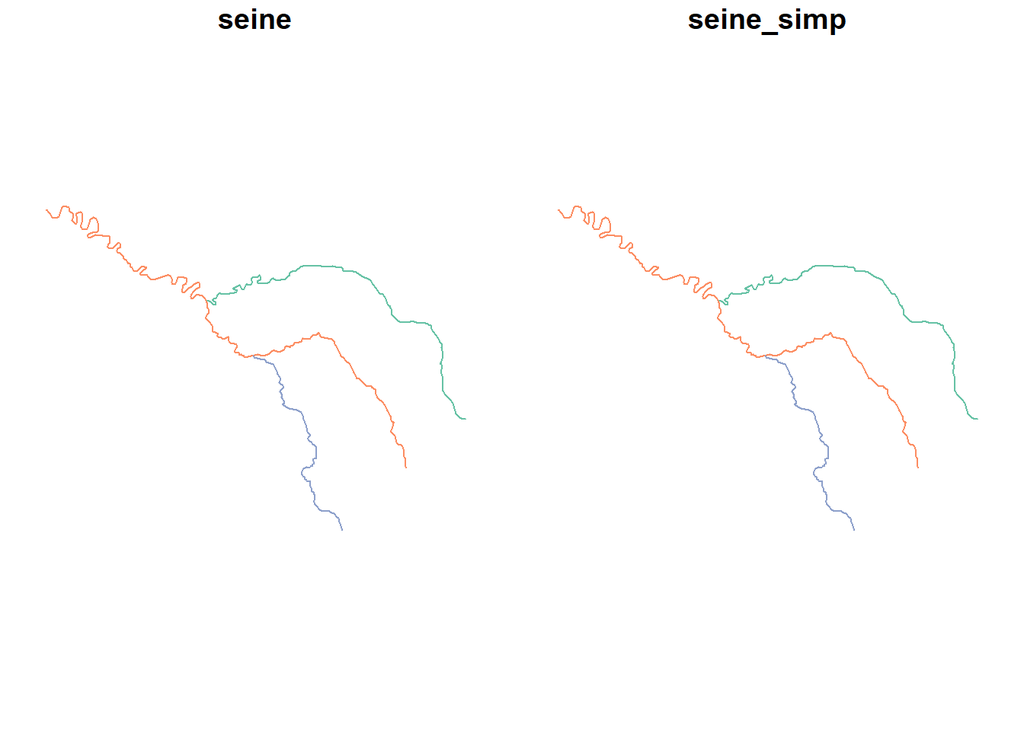

```r
par(mfrow=c(1,2)) # break the plot window to 2 columns
plot(seine, main="seine", key.pos=NULL, reset = F) # set reset to false to get two plots in the same plot window
plot(seine_simp, main="seine_simp", key.pos=NULL, reset = F)
```

```r
par(mfrow=c(1,1))
```

### Centroids

Calculates the center of mass of a spatial object, we use st_centroids() function. To ensure the points are inside the geometry of the parent object, we use st_point_on_surface() function. The two functions assumes attributes are constant over geometries of x. This means the surface is assumed to be flat without indents or bumps.

```r
seine_cen = st_centroid(seine)
seine_pos = st_point_on_surface(seine)# ensures the point is inside the object
class(seine_cen); class(seine_pos)
```

```
## [1] "sf"         "data.frame"
```

```
## [1] "sf"         "data.frame"
```

Plot of the centroid and point on surface.

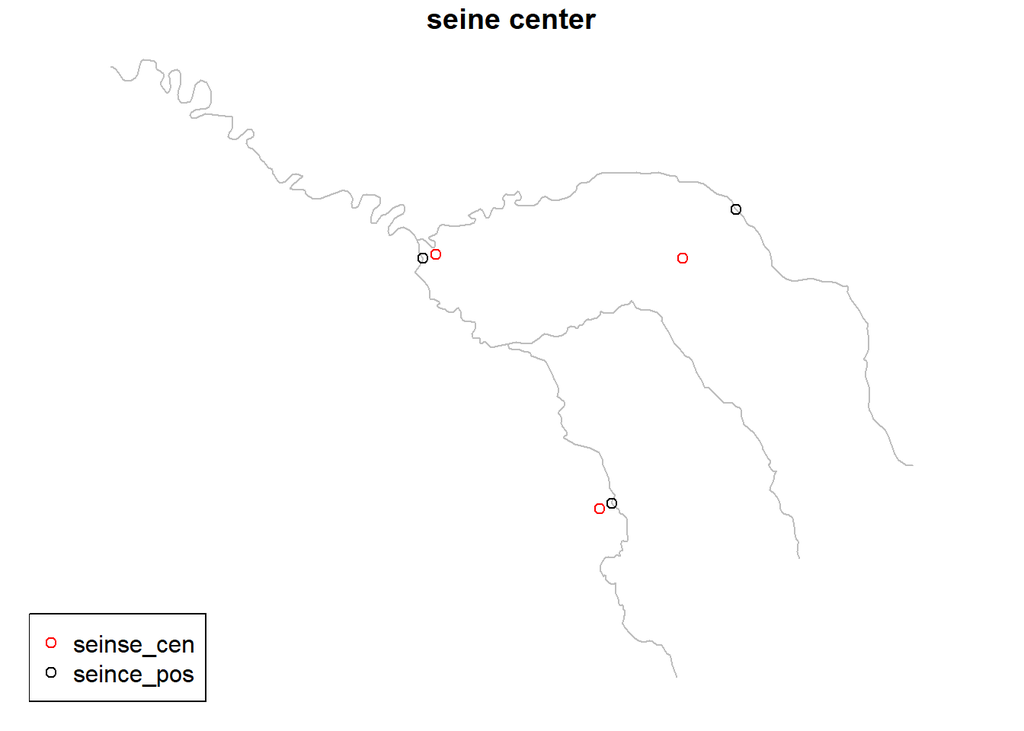

```r
plot(seine, main="seine center", reset=F, col="grey")
plot(seine_cen, add=T, col="red") # add=T will add to the same plot
plot(seine_pos, add=T, col="black")
legend("bottomleft", c("seinse_cen","seince_pos"), col=c("red","black"), pch=c(1,1))
```

### Distance between objects

Compute Euclidean or great circle distance between pairs of geometries (the centroids we captured earlier in this case).

```r
st_distance(seine_cen[1,], seine_cen[2,])
```

```
## Units: [m]
##          [,1]
## [1,] 111458.4
```

### Buffer

A buffer creates a polygon of a given distance around a geometric feature (point, line or polygon).

```r
st_crs(seine)$units_gdal # check unit
```

```
## [1] "metre"
```

```r
st_length(seine)
```

```
## Units: [m]
## [1] 363610.5 635526.7 219244.6
```

```r
seine_buff = st_buffer(seine, dist = 50000) # 50km buffer
```

Plot of the buffers with the river network in black.

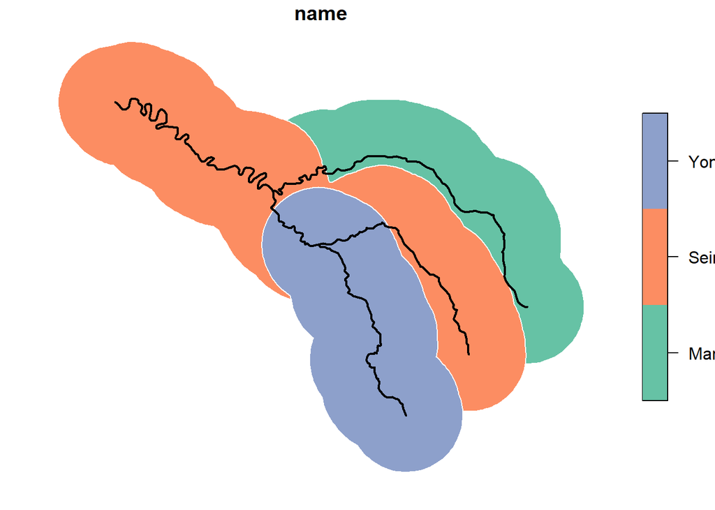

```r
plot(seine_buff, border="white", reset=F)
plot(seine, col="black", lwd=2,add=T)
```

### Clip operations

```r
seine_buff
```

```
## Simple feature collection with 3 features and 1 field
## Geometry type: POLYGON
## Dimension:     XY
## Bounding box:  xmin: 468354.5 ymin: 6610440 xmax: 929940.4 ymax: 6988858
## Projected CRS: RGF93 / Lambert-93
##    name                       geometry
## 1 Marne POLYGON ((637733.5 6811210,...
## 2 Seine POLYGON ((706315.1 6865632,...
## 3 Yonne POLYGON ((800186.6 6711718,...
```

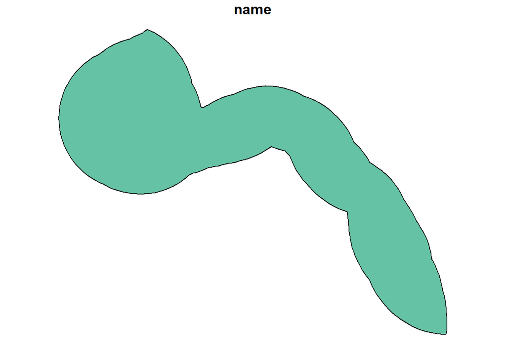

```r
x = seine_buff[1,] # buffer of Marne
y = seine_buff[2,] # buffer of Seine
xANDy = st_intersection(x, y); plot(xANDy["name"])
```